# Clustering Analysis

# Date: “June 5 2017”

# Clustering Analysis in Cardinal

This analysis was preformed using a dataset without slide background information and done with a datamatrix of 2508 Peaks by 20920 Pixels. The tissue, sox and mox channels were determined through microscopy techniques and dimenions were reduced to match the maldi-msi dataset (done by Benedikt). Please see data processing and peak picking scripts to see how data dimensions were reduced. See data clustering script to determine how clusters were generated.

Set up working space

```r
rm(list=ls())
library(Cardinal)
library(ggplot2)
library(reshape2)
load('../Results/cluster-analysis-final.RData') ##ssc clustering
load('../Results/Cardinal_Processed_Data.RData')
```

### Shrunken Centriods Clustering

From the cardinal workflows document:

“The spatial shrunken centroids clustering method for statistical analysis we introduce in Cardinal in the spatialShrunkenCentroids method.

The Gaussian and adaptive weights are retained from the spatially-aware k-means clustering [3]. In addition, we introduce statistical regularization as in nearest shrunken centroids to enforce feature sparsity [4]. This means doing feature selection, so that the analysis automatically identifies informative m/z values."

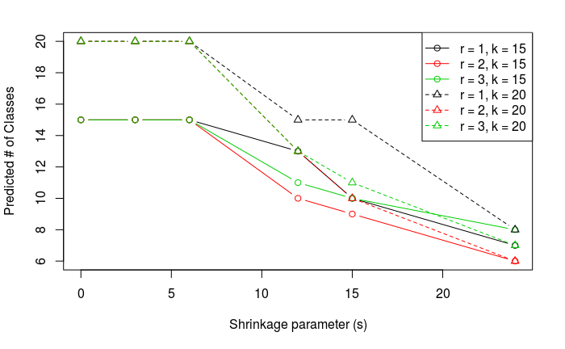

```r
plot(summary(ssc.a))
```

```r
summary(ssc.a)
```

```
   r  k  s   method     time Predicted # of Classes Mean # of Features per Class
1  1 15  0 adaptive  448.837                     15                         2508
2  1 15  3 adaptive  458.728                     15                          530
3  1 15  6 adaptive  460.153                     15                          252
4  1 15 12 adaptive  952.794                     13                           92
5  1 15 15 adaptive  743.132                     10                           82
6  1 15 24 adaptive  659.919                      7                           58
7  1 20  0 adaptive  561.465                     20                         2508
8  1 20  3 adaptive  590.554                     20                          441
9  1 20  6 adaptive  593.128                     20                          188
10 1 20 12 adaptive 1264.981                     15                           83
11 1 20 15 adaptive  926.579                     15                           54
12 1 20 24 adaptive  799.073                      8                           50
13 2 15  0 adaptive 1069.382                     15                         2508
14 2 15  3 adaptive 1102.723                     15                          525
```

[output cut: 22 more lines]

We want to keep the shrinkage parameter as low as possible with getting the “best”" number of clusters

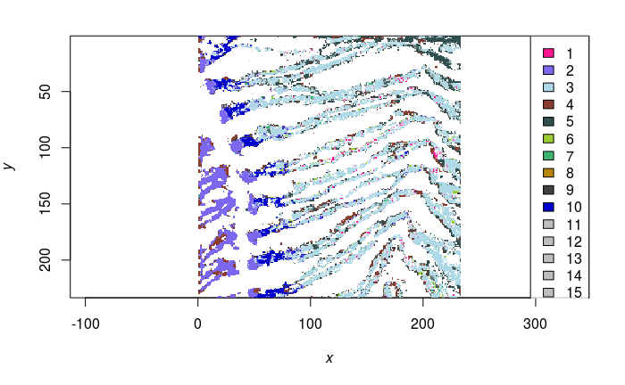

Plot each cluster group independently and choose top three ions that are part of that cluster

```r
pdf('Cluster-Distribution-Plots.pdf', height=6, width=11)
 for (i in 1:10){
   summaryPlots(maldifishmz,ssc.a,model=mod,segment=i, name='', col=mycol)
 }
dev.off()
```

```r
ggsave('../Results/Cluster Membership.eps')
```

Write a datatable for the significant ions across clusters

|  | mz | r | k | s | classes | centers | tstatistics | p.values | adj.p.values |
| --- | --- | --- | --- | --- | --- | --- | --- | --- | --- |
| 1 | 480.3454 | 2 | 15 | 12 | 2 | 4184.98562 | 86.018357 | 0.000000e+00 | 0.000000e+00 |
| 2 | 1124.1758 | 2 | 15 | 12 | 4 | 3163.71374 | 83.723647 | 0.000000e+00 | 0.000000e+00 |
| 3 | 988.1568 | 2 | 15 | 12 | 4 | 4916.04639 | 82.256451 | 0.000000e+00 | 0.000000e+00 |
| 4 | 953.1206 | 2 | 15 | 12 | 4 | 3600.74937 | 82.062824 | 0.000000e+00 | 0.000000e+00 |
| 5 | 817.1032 | 2 | 15 | 12 | 4 | 6245.80402 | 80.861339 | 0.000000e+00 | 0.000000e+00 |
| 6 | 1089.1375 | 2 | 15 | 12 | 4 | 2101.92727 | 80.845318 | 0.000000e+00 | 0.000000e+00 |
| 7 | 954.1238 | 2 | 15 | 12 | 4 | 1906.58365 | 79.998734 | 0.000000e+00 | 0.000000e+00 |
| 8 | 989.1613 | 2 | 15 | 12 | 4 | 2650.91475 | 79.566877 | 0.000000e+00 | 0.000000e+00 |
| 9 | 1125.1790 | 2 | 15 | 12 | 4 | 1920.38999 | 79.262220 | 0.000000e+00 | 0.000000e+00 |
| 10 | 818.1072 | 2 | 15 | 12 | 4 | 2842.92707 | 78.488688 | 0.000000e+00 | 0.000000e+00 |

[output cut: 628 more lines]

One thing interesting, there doens’t seem to be any ions seperating cluster 8 from the other clusters.

```r
table(ssc.a$classes$`r = 2, k = 15, s = 12`)
```

[output not shown]

Make similar % cluster identity barplot for ions that are of interest (i.e., significnat in seperating the groups)

```r
pdf('ion differences')
cols<-colorRampPalette(c('black','blue','lightblue'))
par(mfrow=c(1,2))
mzval<-482.361
image(maldifishmz_3grps,mz=mzval, col.regions=cols(50))
temp<-prct_of_sgnls[grep(mzval,prct_of_sgnls$mz),2:4]
vec<-as.matrix(temp)
barplot(height=vec, main='% of FISHed cells with ion intensity > 0 ')
cols<-colorRampPalette(c('black','blue','lightblue'))
par(mfrow=c(1,2))
mzval<-546.489
image(maldifishmz_3grps,mz=mzval, col.regions=cols(50))
temp<-prct_of_sgnls[grep(mzval,prct_of_sgnls$mz),2:4]
vec<-as.matrix(temp)
barplot(height=vec, main='% of FISHed cells with ion intensity > 0 ')
mzval<-562.483
par(mfrow=c(1,2))
image(maldifishmz_3grps,mz=mzval, col.regions=cols(50))
temp<-prct_of_sgnls[grep(mzval,prct_of_sgnls$mz),2:4]
vec<-as.matrix(temp)
barplot(height=vec, main='% of FISHed cells with ion intensity > 0 ')
mzval<-732.554
par(mfrow=c(1,2))
cols<-colorRampPalette(c('black','blue','lightblue'))
image(maldifishmz_3grps,mz=mzval, col.regions=cols(50))
temp<-prct_of_sgnls[grep(mzval,prct_of_sgnls$mz),2:4]
vec<-as.matrix(temp)
barplot(height=vec, main='% of FISHed cells with ion intensity > 0 ')
mzval<-773.23
par(mfrow=c(1,2))
cols<-colorRampPalette(c('black','blue','lightblue'))
image(maldifishmz_3grps,mz=mzval, col.regions=cols(50))
temp<-prct_of_sgnls[grep(mzval,prct_of_sgnls$mz),2:4]
vec<-as.matrix(temp)
barplot(height=vec, main='% of FISHed cells with ion intensity > 0 ')
mzval<-756.554
par(mfrow=c(1,2))
cols<-colorRampPalette(c('black','blue','lightblue'))
image(maldifishmz_3grps,mz=mzval, col.regions=cols(50))
temp<-prct_of_sgnls[grep(mzval,prct_of_sgnls$mz),2:4]
vec<-as.matrix(temp)
barplot(height=vec, main='% of FISHed cells with ion intensity > 0 ')
dev.off()
```

#### Dendrogram of cluster groups

[figure not shown]

Make a nice plot for a figure

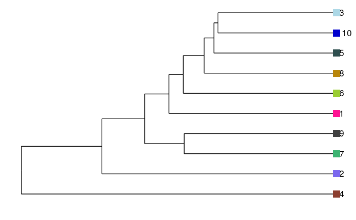

```r
dhc <- as.dendrogram(clusters)
ddata <- dendro_data(dhc, type = "rectangle",)
ddata$labels$label<-as.numeric(gsub('ssca_cluster-',' ',ddata$labels$label))
ddata$labels<-ddata$labels[order(ddata$labels$label),]
ggplot() + geom_segment(data = ddata$segments, aes(x = x, y = y, xend = xend, yend = yend)) +
            geom_text(data = ddata$labels, aes(x = x, y = y, label = label, size = 3, vjust = 0.5, hjust=-0.5)) +
            geom_point(data=label(ddata), aes(x=x, y=y, color=as.factor(label),size=3),shape=15) +
            theme_dendro() + scale_y_reverse() + coord_flip() + scale_color_manual(values=mycol)  + guides(color=F, size=F)
```

### Supervised Shrunken Centriods Clustering

Creat a cross valiadation group

```r
maldifishmz$cvgroup<-cut(maldifishmz$y, breaks=5, labels = F) #based on y-location value in dataset
```

Add in cilliated edge pixels

```r
grps<-ssc.a$classes$`r = 2, k = 15, s = 12`
ciliatedgrps<-grps[which(grps==2)]
grp1<-names(ciliatedgrps)
msidata<-maldifishmz
pData(msidata)[rownames(pData(msidata)) %in% grp1,'Class']<-'CiliatedEdge'
table(msidata$Class, msidata$cvgroup)
```

Run spatial shrunken centriods supervised clustering using the adaptive method and the associated parameters

```r
ssca<-spatialShrunkenCentroids(x=msidata, y=msidata$Class, s=0, r=3)
summary(ssca)
ssca
plot(ssca, mode='tstatistics')
```

[output not shown]

```r
image(ssca, model=list(r=3, s=0), col=c('midnightblue','mediumseagreen','lightcoral','skyblue'))
```

[output not shown]

```r
tp<-topLabels(ssca, n=20000)
dim(tp)
table(tp$classes)
tp.sig<-tp[which(tp$adj.p.values < 0.2),]
write.csv(tp.sig,file='../Results/ssc-classification-sigions.csv')
```